# An exploration of the geography of Toronto's built environment

## Introduction

The purpose of this study is to use data to understand the geography of Toronto's built environment. The data used to achieve this is a socio-economic dataset at a neighbourhood resolution and an enhanced building dataset. Python was used in this study because it is widely adopted in geocomputation having bespoke spatial open-source packages.

```python
##ensure plots render inside notebook
%matplotlib inline

#for advanced maths
import numpy as np
#used for working with dataframes
import pandas as pd
#manipulate spatial data
import geopandas as gpd
##add web maps as background
import contextily as cx
# used for generating plots
import seaborn as sns
#general visualisation utilities
import matplotlib.pyplot as plt
#used for plotting figures - options here display colorbar
from matplotlib.cm import ScalarMappable
#used for altering figure format
import matplotlib.gridspec as gridspec
#spatial package used to build spatial weights matrix
from pysal.lib import weights
#packages used for ESDA
import esda
from splot.esda import moran_scatterplot, lisa_cluster, plot_local_autocorrelation
from esda.moran import Moran_Local
#used for making choropleths
import mapclassify
#for faster spatial processing
from scipy.spatial import cKDTree
#for spatial processing
from shapely.geometry import Point, LineString, box, Polygon
#for spatial processing
from osgeo import gdal
#for processing raster data
import rasterio
from rasterio.merge import merge
from rasterio.plot import show
#used to retrieve file names
import glob
#used for access to OS maps
import os
#for generating clusters
from sklearn import cluster
#library for reading osm data
import pyrosm
#for geospatial indexing
import h3
#for morphological measuring - here for line data
from momepy import Linearity
```

# Part 1

### Variables and concepts

The selected variables were ‘bedrooms_0’ and ‘bedrooms_1’, the varying spatial distribution of these have powerful implications. The number of bedrooms inherently indicates the size, type and value of the associated property (Zietz et al., 2007). The selected variables were aggregated into one derived variable (‘bedrooms_less2’).

Each neighbourhood geometry is different which is a consideration when comparing their associated attribute values. An equal number of properties may exist in 2 neighbourhoods, but one could have a larger area. This is described by the modifiable areal unit problem (MAUP) (Openshaw, 1984). Data ‘munging’ was performed to mitigate this problem. The ‘bedroom_’ prefixed variables were aggregated into a ‘Total’ for each neighbourhood, allowing ‘bedrooms_less2’ to be expressed as a percentage of the total. This approach helps achieve improved representation of the spatial distribution across areal units for easier direct comparison.

### Datasets

```python
#Datasets
#Open Neighbourhoods dataset
neis = gpd.read_file("https://darribas.org/gds_course/_downloads/a2bdb4c2a088e602c3bd6490ab1d26fa/toronto_socio-economic.gpkg")
#load in buildings
buildings_tc = gpd.read_file("C:\\ENVS563 - GEOGRAPHIC DATA SCIENCE\\Assessment\\Data\\mytestdata\\Toronto_buildings_wgs84.shp")
#load in address points
point_tc = gpd.read_file("C:\\ENVS563 - GEOGRAPHIC DATA SCIENCE\\Assessment\\Data\\mytestdata\\Address_point_wgs84.shp")
#Return OSM pbf file with specified bounds
osm = pyrosm.OSM("planet_-79.575,43.592_-79.121,43.853.osm.pbf")
# Raster opened in code (memory reasons)
```

### Choropleth maps and spatial autocorrelation

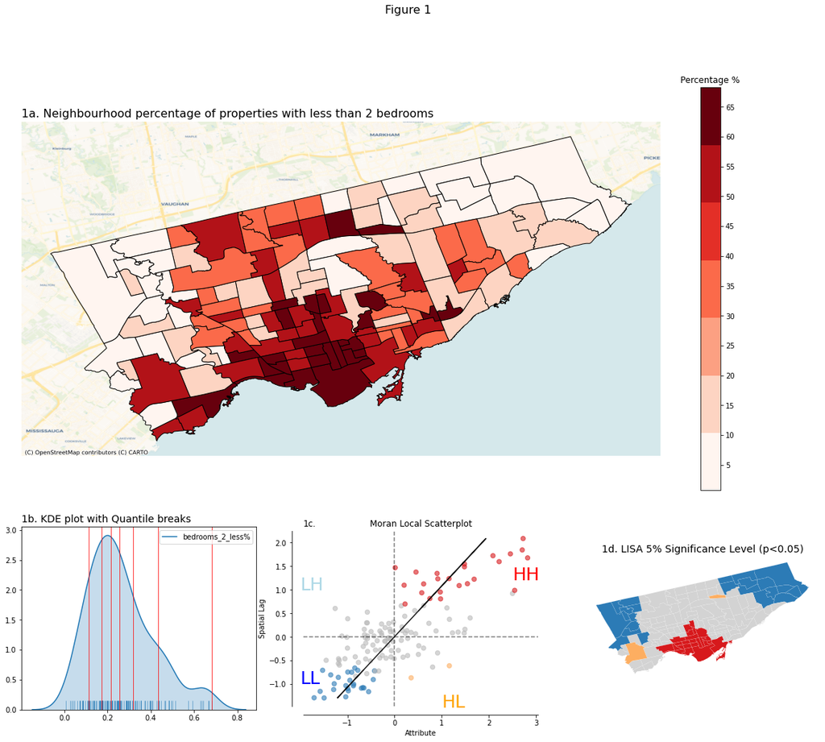

```
0.5456841663263989
```

```python
##calculate derived variables
neis['Total_buildings'] = neis[['bedrooms_0', 'bedrooms_1', 'bedrooms_2', 'bedrooms_3', 'bedrooms_4+']].sum(axis = 1, skipna = True)
neis['bedrooms_2_less%'] = neis[['bedrooms_0', 'bedrooms_1' ]].sum(axis = 1, skipna = True)/neis['Total_buildings']
#drop duplicate _id
neis = neis.drop_duplicates('_id')
# Create spatial weights matrix
w_queen = weights.Queen.from_dataframe(neis, idVariable="_id")
# Row standardize the matrix
w_queen.transform = 'R'
#stanadrise variable
neis['bedrooms_2_less%_std'] = (neis['bedrooms_2_less%'] - neis['bedrooms_2_less%'].mean()) / neis['bedrooms_2_less%'].std()

#Generate figure size as 20x16
fig4 = plt.figure(figsize=(20, 16))
#layout 3cols by 3rows
spec4 = fig4.add_gridspec(ncols=3, nrows=3)
anno_opts = dict(xy=(0.5, 0.5), xycoords='axes fraction',
                 va='center', ha='center')
#generate subplots in 1-over-3 formation
f4_ax1 = fig4.add_subplot(spec4[-1, :-2])
f4_ax2 = fig4.add_subplot(spec4[:-1, :])
f4_ax3 = fig4.add_subplot(spec4[2, 1])
f4_ax4 = fig4.add_subplot(spec4[-1, -1])

fig4.suptitle('Figure 1', fontsize=16)


#Generate histogram and rugplot on axis1
#attribute for quantiles
classi = mapclassify.Quantiles(neis["bedrooms_2_less%"], k=7)
# Plot the kernel density estimation (KDE)
sns.kdeplot(neis["bedrooms_2_less%"], shade=True, ax = f4_ax1)
# Add a blue tick for every value at the bottom of the plot (rugs)
sns.rugplot(neis["bedrooms_2_less%"], alpha=0.5, ax = f4_ax1)
# Loop over each break point and plot a vertical red line
for cut in classi.bins:
    f4_ax1.axvline(cut, color='red', linewidth=0.75)
#set title
f4_ax1.set_title('1b. KDE plot with Quantile breaks', fontsize=14,loc='left')

##Genrate Colorbar as legend
#generate max and min
beds_pct_mx =(neis['bedrooms_2_less%'].max()*100)
beds_pct_mn = (neis['bedrooms_2_less%'].min()*100)
#generate colorbar
cmap=plt.cm.get_cmap('Reds', 7)
#use range and normalise for colorbar
norm1 = plt.Normalize(beds_pct_mn, beds_pct_mx)
sm1 =  ScalarMappable(norm=norm1, cmap=cmap)
#plot colorbar with choropleth, vertical orientation and increments of 5
cbar1 = fig4.colorbar(sm1, ax=f4_ax2, orientation = 'vertical', ticks=range(0,80,5))
#set title
cbar1.ax.set_title("Percentage %")

# Plot the choropleth on axix2
neis.plot(column='bedrooms_2_less%', ax=f4_ax2, scheme='quantiles', cmap=plt.cm.get_cmap('Reds', 7), legend=False, edgecolor='k')
# Remove axis clutter
f4_ax2.set_axis_off()
# Set the axis title to the name of variable being plotted
f4_ax2.set_title('1a. Neighbourhood percentage of properties with less than 2 bedrooms', fontsize=16,loc='left')
# Add basemap
cx.add_basemap(ax=f4_ax2, source=cx.providers.CartoDB.Voyager,
               crs="EPSG:4326"
              )

#Generate and display Moran local scatterplot on axis3
moran_loc = Moran_Local(neis['bedrooms_2_less%_std'].values, w_queen)
scat = moran_scatterplot(moran_loc, p=0.05, ax=f4_ax3)
#plot labels
f4_ax3.text(2.5, 1.2, "HH", fontsize=25,  color = 'Red')
f4_ax3.text(1, -1.5, "HL", fontsize=25,  color = 'Orange')
f4_ax3.text(-2, 1, "LH", fontsize=25 , color = 'LightBlue')
f4_ax3.text(-2, -1, "LL", fontsize=25, color = 'Blue')
f4_ax3.set_title("1c.",loc='left')

#Generate and display results of Moran plot on axis4
lisa = esda.Moran_Local(neis['bedrooms_2_less%'], w_queen)
lisa_cluster(lisa, neis, p=0.05, ax=f4_ax4, legend = False)
f4_ax4.set_title("1d. LISA 5% Significance Level (p<0.05)", fontsize=14)

#plot figure
plt.show()

mi = esda.Moran(neis['bedrroms_2_less%'], w_queen)
mi.I
```

### Spatial autocorrelation

1a shows that globally there is a pattern of clustering in the distribution of high percentage ‘bedrooms_less2%’ neighbourhoods concentrated centrally towards the South (60%+). In order to further interpret the pattern in a statistical manner a spatial weights matrix was calculated using queen contiguity. This acts as a framework to calculate the ‘spatial lag’; the mean of the variable in the neighbourhood of the observation. The Moran plot in 1c shows, from the line of best fit, that there is positive spatial autocorrelation with a Morans I value of 0.54 (p<0.05). This means neighbourhoods with high ‘bedrooms_less2%’ values are located near others with high ‘bedrooms_less2%’ values.

1d isolates cluster locations in relation to their labelled quadrant in 1c, identifying local spatial autocorrelation. The coloured points in 1c (same colour as labels) are statistically significant (P<0.05). The result in 1d identifies a ‘hot-spot’ to the south, ‘cold-spots’ to the north-west and north-east suburbs and outliers to the West.

## Part 2 - Regionalisation

### 1. Join address points to building data

```python
#Generate a list of column names from the buildings and points for filtering
columns_list_buildings = ['fid','Longitude','Latitude','Shape_Area','geometry','Build_ID']
columns_list_points = ['GEO_ID','FCODE','FCODE_DES','OBJECTID','geometry']
#filter buildings and address points
buildings_tc = buildings_tc[columns_list_buildings]
point_tc = point_tc[columns_list_points]
#transform to projected CRS
buildings_tc = buildings_tc.to_crs('EPSG:3979')
point_tc = point_tc.to_crs('EPSG:3979')

#spatialjoin address points and building polygons
points_address_tc = gpd.sjoin(point_tc,buildings_tc , how="left", op='intersects')
buildings_address_tc = gpd.sjoin(buildings_tc, point_tc , how="left", op='intersects')
#establish buildings and points not joined by filtering null associated primary key
needed_points_address_tc = points_address_tc[points_address_tc.Build_ID.isnull()]
needed_buildings_address_tc = buildings_address_tc[buildings_address_tc.GEO_ID.isnull()]
joined_buildings_address_tc = buildings_address_tc[buildings_address_tc.GEO_ID.notnull()]
#generate copy from slice
joined_buildings_address_tc = joined_buildings_address_tc.copy()
needed_buildings_address_tc2 = needed_buildings_address_tc.copy()

#attain building centroids as seperate attribute (used later in spatial joining process)
joined_buildings_address_tc['building_centroid'] = joined_buildings_address_tc.centroid
needed_buildings_address_tc2['building_centroid'] = needed_buildings_address_tc2.centroid

#reset indexes for the buildings and points ready for re-merging
needed_buildings_address_tc2 = needed_buildings_address_tc2.reset_index()
needed_points_address_tc = needed_points_address_tc.reset_index()

#drop null columns that will be later be gained from join with nearest address point
needed_buildings_address_tc2 = needed_buildings_address_tc2.drop(['FCODE','FCODE_DES','GEO_ID'],  axis=1)
```

### 2. Infer unjoined

```python
#define function for establishing nearest 'unmatched' points to building centroid, uses lambda function and KDTree for fast processing
#appends columns for those missing in join and distance value
def ckdnearest(gdA, gdB):
    nA = np.array(list(gdA.building_centroid.apply(lambda x: (x.x, x.y))))
    nB = np.array(list(gdB.geometry.apply(lambda x: (x.x, x.y))))
    btree = cKDTree(nB)
    dist, idx = btree.query(nA, k=1)
    gdf = pd.concat(
        [gdA.reset_index(drop=True), gdB.loc[idx, gdB.columns.isin(['GEO_ID','FCODE','FCODE_DES'])].reset_index(drop=True),
         pd.Series(dist, name='dist')], axis=1)
    return gdf

#use function described above
build_address_tc = ckdnearest(needed_buildings_address_tc2, needed_points_address_tc)
#add a distance of zero to those already joined
joined_buildings_address_tc['dist'] = 0
#
#drop index column to enable data to re-merge original table
build_address_tc = build_address_tc.drop(build_address_tc.columns[0],  axis=1)

#concatenate gdf for inferred and original join and set types to integer
full_building_table_tc = pd.concat([build_address_tc ,joined_buildings_address_tc])
full_building_table_tc = full_building_table_tc.astype({'FCODE': 'int', 'GEO_ID': 'int', 'fid': 'int'})

#delete obsolete variables
del needed_points_address_tc
del needed_buildings_address_tc2
del build_address_tc
del joined_buildings_address_tc
```

### 3. Append number of addresses intersecting with each building

```python
#return number of addresses per building and rename attribute as count
grouped_build = full_building_table_tc.groupby(['Build_ID'])['fid'].count().reset_index()
grouped_build.rename(columns = {'fid':'Count'}, inplace = True)
##
#new table after merging on building ID
build_count = pd.merge(full_building_table_tc,grouped_build,on='Build_ID')

#remove entries where distance-vector is over 10m (too far)
build_count = build_count.query('dist < 10')

#remove duplicates
build_count = build_count.copy()
build_count.drop_duplicates(subset ="fid",
                     keep = 'first', inplace = True)

#Infer buildings with area less than 250m are residential
build_count['FCODE_DES'].mask((build_count['FCODE_DES'] == 'Unknown') & (build_count['Count'] == 1) & (build_count['Shape_Area'] < 250 ), 'Inferred Residential', inplace=True)

#re-gather types of building counts to know inferred number (optionally inspect them)
grouped_types_2 = build_count.groupby(['FCODE_DES'])['fid'].count().reset_index()
grouped_types_2.rename(columns = {'fid':'Count'}, inplace = True)
```

### 4. Generate building heights

```python
#generate new building centroid table with a geoemtry column
Building_centroids = build_count[['Build_ID','building_centroid']]
Building_centroids = Building_centroids.copy()
Building_centroids.rename(columns = {'building_centroid':'geometry'}, inplace = True)
Building_centroids = gpd.GeoDataFrame(Building_centroids, crs="EPSG:3979", geometry='geometry')

#get DTM values
# Read points from shapefile
Building_centroids.index = range(len(Building_centroids))
coords = np.array(list(Building_centroids.geometry.apply(lambda x: (x.x, x.y))))
# Open the raster
src = rasterio.open('C:\\ENVS563 - GEOGRAPHIC DATA SCIENCE\\Raster\\DTM\\Toronto_DTMx1m_Mosaic_NAD84.tif')
# Sample the raster at every point location and store values in DataFrame
Building_centroids['DTM Value'] = [x for x in src.sample(coords)]
Building_centroids['DTM Value'] = [x[0] for x in src.sample(coords)]

# Read points from shapefile
Building_centroids.index = range(len(Building_centroids))
coords = np.array(list(Building_centroids.geometry.apply(lambda x: (x.x, x.y))))
# Open the raster
src = rasterio.open('C:\\ENVS563 - GEOGRAPHIC DATA SCIENCE\\Raster\\DSM\\Toronto_DSMx1m_Mosaic_NAD84.tif')
# Sample the raster at every point location and store values in DataFrame
Building_centroids['DSM Value'] = [x for x in src.sample(coords)]
Building_centroids['DSM Value'] = [x[0] for x in src.sample(coords)]

#generate building heights subtracting DTM from DSM, remove unrequired columns
Building_centroids['Building Height'] = Building_centroids['DSM Value'] - Building_centroids['DTM Value']
Building_centroids = Building_centroids.drop(['geometry','DTM Value','DSM Value'],  axis=1)
del src
```

### 5. Recode building use

```python
#merge the building_heights with the main building table
build_count = pd.merge(build_count,Building_centroids,on='Build_ID')

#Categorise into 4 groups of:
#residential
build_count['FCODE_DES'].mask(build_count['FCODE_DES'].str.contains('Residential') , 'Residential', inplace=True)
#hospitality
build_count['FCODE_DES'].mask(build_count['FCODE_DES'].str.contains('Shop|Restaurant|Hotel|Hostel|Gym|Museum|Art|Cinema|Sport') , 'Hospitality', inplace=True)
#utilities
build_count['FCODE_DES'].mask(build_count['FCODE_DES'].str.contains('Airport|Transport|Station|Airport|Police|Hall|Worship|School|Uni|Service|Library|Bus') , 'Utilities', inplace=True)
#tertiary
build_count['FCODE_DES'].mask(build_count['FCODE_DES'].str.contains('Commercial|Office') , 'Tertiary', inplace=True)
#other
build_count['FCODE_DES'].mask(~build_count['FCODE_DES'].str.contains('Residential|Hospitality|Utilities|Tertiary') , 'Other', inplace=True)
grouped_types_2 = build_count.groupby(['FCODE_DES'])['fid'].count().reset_index()
grouped_types_2.rename(columns = {'fid':'Count'}, inplace = True)
```

### 6. Aggregate buildings and their attributes using a hex-grid

```python
#drop geometry column , reindex and make the 'centoroid' the 'geoemtry' in order to sjoin
build_count_result = build_count.drop(['geometry'],  axis=1)
build_count_result = build_count.reindex()
build_count_result.rename(columns = {'building_centroid':'geometry'}, inplace = True)

#Return OSM pbf file with specified bounds
##osm = pyrosm.OSM("planet_-79.575,43.592_-79.121,43.853.osm.pbf")

#get bounds of pbf file
boundaries = osm.get_boundaries()
limits = gpd.GeoSeries([boundaries.unary_union.convex_hull],
                             crs=boundaries.crs
                            )

#establish zoom level and number of hexs
zoom = 8
hexs = h3.polyfill(limits.geometry[0].__geo_interface__,
                   9,
                   geo_json_conformant = True
                  )
print(f"Zoom: {zoom} | No. of hexs: {len(hexs)}")

polygonise = lambda hex_id: Polygon(
                                h3.h3_to_geo_boundary(
                                    hex_id, geo_json=True)
                                   )
#genrerate polys with crs 4329
all_polys = gpd.GeoSeries(list(map(polygonise, hexs)), \
                                      index=hexs, \
                                      crs="EPSG:4326" \
                                     )
#make the new polygon set a gdf and reproject to crs:4326
all_polys = gpd.GeoDataFrame({"geometry": all_polys.geometry,
                                              "hid": all_polys.index
                                             }, crs="EPSG:4326")
all_polys = all_polys.to_crs('EPSG:3979')
###
build_count_result = build_count.drop(['geometry'],  axis=1)
build_count_result.rename(columns = {'building_centroid':'geometry'}, inplace = True)

#spatial join the buildings to the hex grid
crosswalk2 = gpd.sjoin(build_count_result, all_polys, how="inner", rsuffix="_areas" )

#add tally column for counts
crosswalk2['tally']=1
```

```
Zoom: 8 | No. of hexs: 7033
```

### 7. Aggregate and dissolve data for regionalisation

```python
 # Assign counts into a fresh table
d = {'tally':'total count', 'Count':'total addresses','Building Height':'Average Building Height'}
crosswalk2_by_area=crosswalk2.groupby('hid').agg({'tally':'sum', 'Count':'sum','Building Height':'mean'}).rename(columns=d)

#make area groupby a dataframe and reset the index
crosswalk2_by_area = pd.DataFrame(crosswalk2_by_area)
crosswalk2_by_area = crosswalk2_by_area.reindex()
crosswalk2_by_area.reset_index(inplace=True)

#create pivot table to count building types in hexagons
pivot = crosswalk2[['hid','FCODE_DES']].reset_index().pivot_table(index='hid', columns='FCODE_DES', aggfunc='count')
pivot = pd.DataFrame(pivot)
pivot = pivot.fillna(0)
pivot.columns = pivot.columns.droplevel()

# join pivot to the areas table
crosswalk2_by_area = pd.merge(crosswalk2_by_area, pivot,on='hid')
joined_hex = pd.merge(all_polys, crosswalk2_by_area, on='hid')

#selection of categories used for kmeans clustering
buildings_cats2 = ['total count', 'total addresses', 'Average Building Height','Tertiary', 'Hospitality','Residential','Other']

#drop null rows (those not successfully joined)
joined_hex = joined_hex.dropna()

#build spatial weights matrix
w = weights.Queen.from_dataframe(joined_hex)
#drop islands in the hex poly dataset
joined_hex = joined_hex.drop(w.islands)
#Rebuild weights
w = weights.Queen.from_dataframe(joined_hex)
joined_hex = joined_hex.reindex()

#make 9 clusters model
db9_final = cluster.AgglomerativeClustering(n_clusters=9, connectivity=w.sparse)

# Run the clustering algorithm using chosen variables
db9cls_final = db9_final.fit(joined_hex[buildings_cats2])

#add labels and make categorical for legend display
joined_hex['db9cls_final'] = db9cls_final.labels_
joined_hex['db9cls_final'] = pd.Categorical(joined_hex.db9cls_final)


#Define function to dissolve hex-grids
def dissolve(gs):
    '''
    Take a series of polygons and dissolve them into a single one
    Arguments
    ---------
    gs        : GeoSeries
                Sequence of polygons to be dissolved
    Returns
    -------
    dissolved : Polygon
                Single polygon containing all the polygons in `gs`
    '''
    return gs.unary_union

# Dissolve the polygons based on 9cls
db_groups = gpd.GeoSeries(joined_hex.groupby(joined_hex['db9cls_final'])\
                                .apply(dissolve),
                             crs=joined_hex.crs
                            )
#make variable a gdf
db_groups = gpd.GeoDataFrame({"geometry": db_groups.geometry,
                                              "cluster": db_groups.index
                                             }, crs="EPSG:3979")
```

### 8. Plot regionalisation

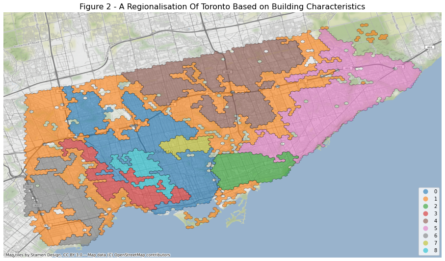

```python
# Set up figure to view result
f, ax = plt.subplots(1, figsize=(16, 16))

# Add regionalisation geography
db_groups.to_crs(epsg=4326)\
            .plot(ax=ax,column='cluster',
                  cmap= 'tab10' , legend = True, legend_kwds={"loc": 4},
                  edgecolor="black",alpha=0.6,
                  linewidth=0.5
                 )

# Add basemap
cx.add_basemap(ax,
               crs="EPSG:4326"
              )
# Add title
plt.title('Figure 2 - A Regionalisation Of Toronto Based on Building Characteristics',  fontsize=16)
# Remove axis
ax.set_axis_off()
# Display map
plt.show()
```

### 9. Print table

```python
# Calculate the mean by group
k9means = joined_hex.groupby('db9cls_final')[buildings_cats2].mean()
# Show the table transposed to 2.dp (so not too wide)
np.round(k9means.T, decimals=2)
```

| db9cls_final | 0 | 1 | 2 | 3 | 4 | 5 | 6 | 7 | 8 |
| --- | --- | --- | --- | --- | --- | --- | --- | --- | --- |
| total count | 77.45 | 27.91 | 166.22 | 131.99 | 85.55 | 79.14 | 98.36 | 161.96 | 200.76 |
| total addresses | 104.94 | 34.09 | 233.02 | 204.71 | 101.73 | 90.66 | 108.76 | 212.47 | 278.93 |
| Average Building Height | 11.27 | 9.56 | 8.09 | 9.04 | 7.71 | 6.72 | 6.94 | 9.92 | 7.85 |
| Tertiary | 1.63 | 0.57 | 1.01 | 1.74 | 0.51 | 0.36 | 0.57 | 2.33 | 1.71 |
| Hospitality | 0.14 | 0.14 | 0.19 | 0.11 | 0.11 | 0.18 | 0.06 | 0.07 | 0.05 |
| Residential | 67.22 | 22.56 | 150.87 | 107.39 | 82.16 | 76.27 | 93.34 | 147.40 | 175.25 |
| Other | 7.79 | 4.38 | 13.11 | 21.83 | 2.32 | 1.98 | 3.98 | 11.23 | 22.39 |

## Conclusion

Comparing the regionalisation to the choropleth map, the regions suggest the urban composition is more complex than administratively defined boundaries indicate. Prior uses of k-means clustering in a spatial context suggest these delineations have capacity to inform town planning (Zhi et al., 2016). Further applications of this regionalisation include predicting house prices, targeting areas for development, identifying regions lacking certain services, habitat delineation and police patrol districting (Wei et al., 2021).

## Bibliography

Besancon, L., M. Cooper, A. Ynnerman, F. Vernier. 2020. An evaluation of visual method for Population Statistics based on Choropleth maps.

Openshaw, S. 1984. Ecological Fallacies and the Analysis of Areal Census Data. Environment and Planning A. 16: 17-31.

Rey, S., D Arribas-Bel, L. Wolf. Geographic Data Science with PySAL and the PyData stack. CRC press. Forthcoming.

Wei, R., S. Rey, E. Knaap. 2021. Efficient regionalization for spatially explicit neighborhood delineation. International Journal of Geographical Information Science. 35:135-151

Zhi, Ye., L Haifeng, D. Wang, M. Deng, S Wang, J Gao, Z Duan, Y Liu. 2016. Latent spatio-temporal activity structures: a new approach to inferring intra-urban functional regions via social media check-in data. Geo-spatial Information Science. 19: 94-105.

Zietz, J., E. Zietz, G. Sirmans. 2007. Determinants of House Prices: A Quantile Regression Approach. The Journal of Real Estate Finance and Economics. 37: 317-333.

## Datasources

Natural Resources Canada. 2017. High Resolution Digital Elevation Model (HRDEM) – CanElavation Series. - -Accessed: 10-12-2020, https://open.canada.ca/data/en/dataset/957782bf-847c-4644-a757-e383c0057995

Parks Canada. 2017. Building Footprints. Accessed: 10-12-2020, https://open.canada.ca/data/en/dataset/aff6b442-1b27-4f24-8546-6b38f96bba1d

Ontario Government and Teranet Enterprises Inc. Municipal Address Points. Accessed: 10-12-2020, https://open.toronto.ca/dataset/address-points-municipal-toronto-one-address-repository/

Social Development, Finance and Administration. Neighbourhood Profiles. Accessed: 10-12-2020, https://open.toronto.ca/dataset/neighbourhood-profiles/

## License

https://open.canada.ca/en/open-government-licence-canada

### Appendix A - Raster mosaicing

```python
#Calculate the raster data using mosaicing - Run on both DTM and DSM
# File and folder paths
dirpath = "C:\\GeographicDataScience\\ENVS563 - GEOGRAPHIC DATA SCIENCE\\Raster\\DTM"
out_fp = os.path.join(dirpath, "Toronto_DTMx1m_Mosaic.tif")

# Make a search criteria to select the DEM files
search_criteria = "DTM*.tif"
q = os.path.join(dirpath, search_criteria)
# glob function can be used to list files from a directory with specific criteria
dem_fps = glob.glob(q)

# List for the source files
src_files_to_mosaic = []

# Iterate over raster files and add them to source -list in 'read mode'
for fp in dem_fps:
    src = rasterio.open(fp)
    src_files_to_mosaic.append(src)

# Merge function returns a single mosaic array and the transformation info
mosaic, out_trans = merge(src_files_to_mosaic)

# Plot the result
show(mosaic, cmap='terrain')

out_meta = src.meta.copy()

# Update the metadata
out_meta.update({"driver": "GTiff",
                 "height": mosaic.shape[1],
                 "width": mosaic.shape[2],
                 "transform": out_trans,
                 "crs": "+proj=utm +zone=17 +ellps=GRS80 +units=m +no_defs "
                 }
                )
```

### Appendix B - Reproject raster

```python
#Appedix 2
#import and reproject raster data for toronto projected CRS
filename = r'C:\\ENVS563 - GEOGRAPHIC DATA SCIENCE\\Raster\\DSM\\Toronto_DSMx1m_Mosaic.tif'
input_raster = gdal.Open(filename)
output_raster = r'C:\\ENVS563 - GEOGRAPHIC DATA SCIENCE\\Raster\\DSM\\Toronto_DSMx1m_Mosaic_NAD84.tif'
gdal.Warp(output_raster,input_raster,dstSRS='EPSG:3979')
```